# Get started with Kotlin/JS

This tutorial shows how to create a web application for the browser using Kotlin/JavaScript (Kotlin/JS). To create your app, choose the tool that best fits your workflow:

- IntelliJ IDEA: clone the project template from version control and work on it in IntelliJ IDEA.
- Gradle build system: create build files for your project manually to better understand how the setup works under the hood.

## Create your application in IntelliJ IDEA

To create your Kotlin/JS web application, you can use [IntelliJ IDEA](https://www.jetbrains.com/idea/download/).

### Set up the environment

1. Download and install the latest version of [IntelliJ IDEA](https://www.jetbrains.com/idea/).
2. Install the [Kotlin Multiplatform IDE plugin](https://plugins.jetbrains.com/plugin/14936-kotlin-multiplatform) (not to be confused with the Kotlin Multiplatform Gradle plugin).

### Create your project

1. In IntelliJ IDEA, select File | New | Project from Version Control.
2. Enter the URL of the [Kotlin/JS template project](https://github.com/Kotlin/kmp-js-wizard):

   ```
   https://github.com/Kotlin/kmp-js-wizard
   ```

3. Click Clone.

### Configure your project

1. Open the `kmp-js-wizard/gradle/libs.versions.toml` file. It contains the version catalog for project dependencies.
2. Make sure the Kotlin version matches the version of the Kotlin Multiplatform Gradle plugin, which is required to create a web application targeting Kotlin/JS:

   ```
   [versions]
   kotlin = "2.4.20"

   [plugins]
   kotlin-multiplatform = { id = "org.jetbrains.kotlin.multiplatform", version.ref = "kotlin" }
   ```

3. Synchronize the Gradle files (if you updated the `libs.versions.toml` file). Click the Load Gradle Changes icon that appears in your build file.

[figure not shown]

   Alternatively, click the refresh button in the Gradle tool window.

For more information about the Gradle configuration for multiplatform projects, see the Multiplatform Gradle DSL reference.

### Build and run the application

[figure not shown]

The web application opens automatically in your browser. Alternatively, you can open the following URL in your browser when the run is finished:

```
   http://localhost:8080/
```

You can see the web application:

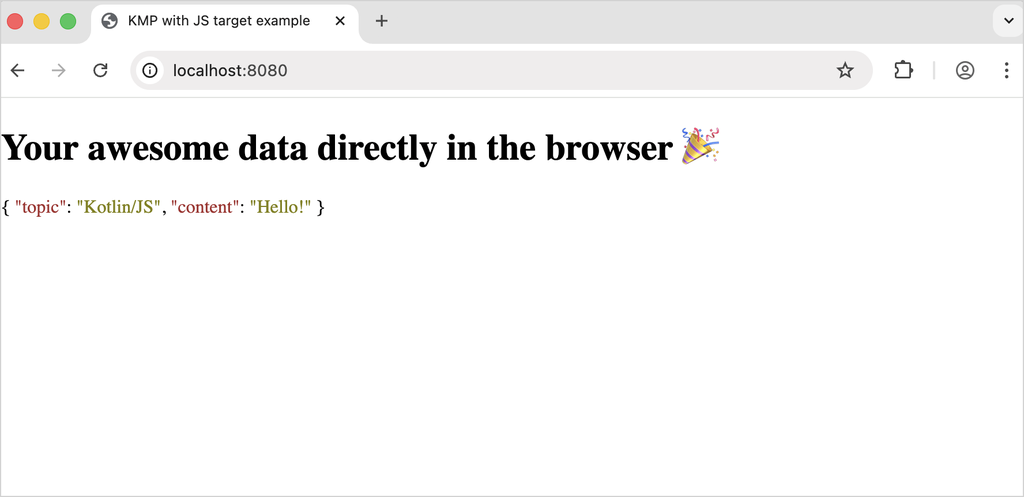

After you run the application for the first time, IntelliJ IDEA creates its corresponding run configuration (jsMain [js]) at the top bar:

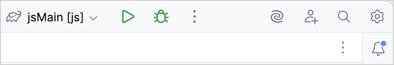

### Enable continuous build

Gradle can automatically rebuild your project whenever you make changes:

1. Select jsMain [js] in the list of run configurations and click More Actions | Edit.

[figure not shown]

2. In the Run/Debug Configurations dialog, enter `jsBrowserDevelopmentRun --continuous` within the Run field.

[figure not shown]

3. Click OK.

Now, when you run the application and make any changes, Gradle automatically performs incremental builds for the project and hot-reloads the browser whenever you save (`Ctrl + S`/`Cmd + S`) or change a class file.

### Modify the application

Modify the application to add a feature that counts the number of letters in a word.

#### Add an input element

1. In the `src/jsMain/kotlin/Main.kt` file, add an [HTML input element](https://developer.mozilla.org/en-US/docs/Web/HTML/Reference/Elements/input) through an extension function to read user input:

   ```
   // Replace the Element.appendMessage() function
   fun Element.appendInput() {
       val input = document.createElement("input")
       appendChild(input)
   }
   ```

2. Call the `appendInput()` function in `main()`. It displays an input element on the page:

   ```
   fun main() {
       // Replace document.body!!.appendMessage(message)
       document.body?.appendInput()
   }
   ```

3. Run the application again.

   Your application looks like this:

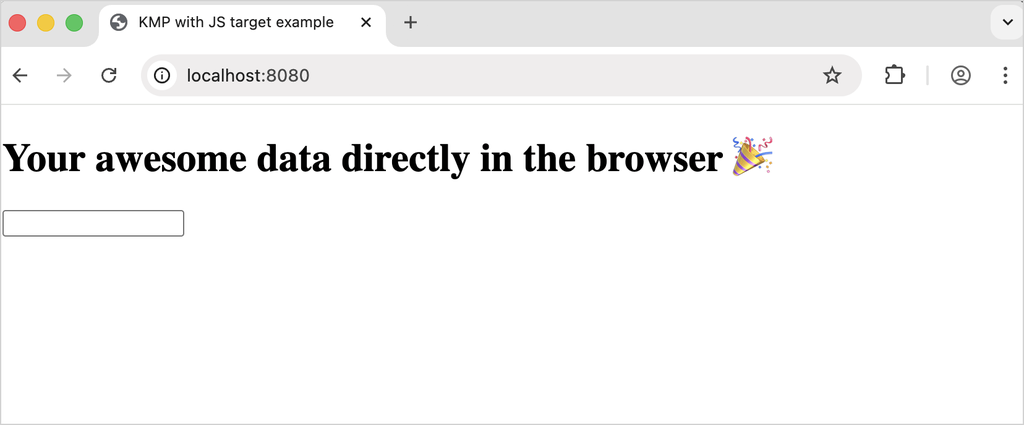

#### Add an input event handling

1. Add a listener inside the `appendInput()` function to read the input value and react to changes:

   ```
   // Replace the current appendInput() function
   fun Element.appendInput(onChange: (String) -> Unit = {}) {
       val input = document.createElement("input").apply {
           addEventListener("change") { event ->
               onChange(event.target.unsafeCast<HTMLInputElement>().value)
           }
       }
       appendChild(input)
   }
   ```

2. Follow the IDE's suggestions to import the `HTMLInputElement` dependency.

[figure not shown]

3. Call the `onChange` callback in `main()`. It reads and handles the input value:

   ```
   fun main() {
       // Replace document.body?.appendInput()
       document.body?.appendInput(onChange = { println(it) })
   }
   ```

#### Add an output element

1. Add a text element to display the output by defining an extension function that creates a paragraph:

   ```
    fun Element.appendTextContainer(): Element {
        return document.createElement("p").also(::appendChild)
    }
   ```

2. Call the `appendTextContainer()` function in `main()`. It creates the output element:

   ```
    fun main() {
        // Creates a text container for our output
        // Replace val message = Message(topic = "Kotlin/JS", content = "Hello!")
        val output = document.body?.appendTextContainer()

        // Reads the input value
        document.body?.appendInput(onChange = { println(it) })
    }
   ```

#### Process the input to count the letters

Process the input by removing whitespace and displaying the output with the number of letters.

Add the following code to the `appendInput()` function within the `main()` function:

```
fun main() {
    // Creates a text container for our output
    val output = document.body?.appendTextContainer()

    // Reads the input value
    // Replace the current appendInput() function
    document.body?.appendInput(onChange = { name ->
        name.replace(" ", "").let {
            output?.textContent = "Your name contains ${it.length} letters"
        }
    })
}
```

From the code above:

- The [`replace()` function](https://kotlinlang.org/api/latest/jvm/stdlib/kotlin.text/replace.html) removes the empty spaces in the name.
- The `let{}` scope function runs the function within the object context.
- The string template (`${it.length}`) inserts the word's length into the string by prefixing it with a dollar sign (`$`) and enclosing it in curly braces (`{}`). Whereas `it` is the default name of a lambda parameter.

#### Run the application

1. Run the application.
2. Enter your name.
3. Press `Enter`.

You can see the result:

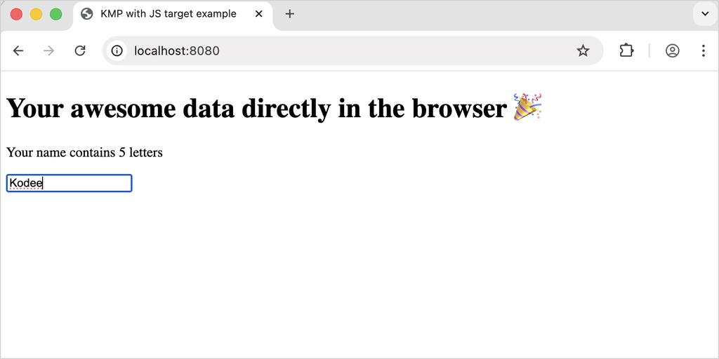

#### Process the input to count unique letters

As an additional exercise, let's process the input to calculate and display the number of unique letters in the word:

1. In the `src/jsMain/kotlin/Main.kt` file, add the `.countDistinctCharacters()` extension function for `String`:

   ```
   fun String.countDistinctCharacters() = lowercase().toList().distinct().count()
   ```

   From the code above:
   - The [`.lowercase()` function](https://kotlinlang.org/api/latest/jvm/stdlib/kotlin.text/lowercase.html) converts the name to lowercase.
   - The [`toList()` function](https://kotlinlang.org/api/latest/jvm/stdlib/kotlin.text/to-list.html) converts the input string to a list of characters.
   - The [`distinct()` function](https://kotlinlang.org/api/latest/jvm/stdlib/kotlin.collections/distinct.html) selects only the distinct characters from the word.
   - The [`count()` function](https://kotlinlang.org/api/latest/jvm/stdlib/kotlin.collections/count.html) counts the distinct characters.
2. Call the `.countDistinctCharacters()` function in `main()`. It counts the unique letters in your name:

   ```
    fun main() {
        // Creates a text container for our output
        val output = document.body?.appendTextContainer()

        // Reads the input value
        document.body?.appendInput(onChange = { name ->
            name.replace(" ", "").let {
                // Prints the number of unique letters
                // Replace output?.textContent = "Your name contains ${it.length} letters"
                output?.textContent = "Your name contains ${it.countDistinctCharacters()} unique letters"
            }
        })
   }
   ```

3. Follow the steps to run the application and enter your name.

You can see the result:

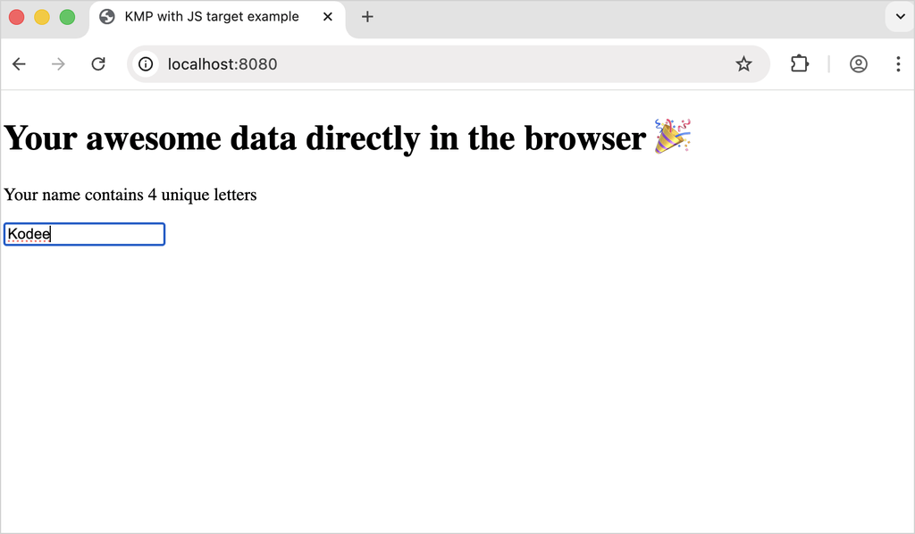

## Create your application using Gradle

In this section, you can learn how to manually create a Kotlin/JS application using [Gradle](https://gradle.org).

Gradle is the default build system for Kotlin/JS and Kotlin Multiplatform projects. It is also commonly used in Java, Android, and other ecosystems.

### Create project files

1. Make sure you use a Gradle version that is compatible with the Kotlin Gradle plugin (KGP). See the compatibility table for more details.
2. Create an empty directory for your project using your file explorer, the command line, or any tool you prefer.
3. Inside the project directory, create a `build.gradle.kts` file with the following content:

   ```
   // build.gradle.kts
   plugins {
       kotlin("multiplatform") version "2.4.20"
   }

   repositories {
       mavenCentral()
   }

   kotlin {
       js {
           // Use browser() for running in a browser or nodejs() for running in Node.js
           browser()
           binaries.executable()
       }
   }
   ```

   ```
   // build.gradle
   plugins {
       id 'org.jetbrains.kotlin.multiplatform' version '2.4.20'
   }

   repositories {
       mavenCentral()
   }

   kotlin {
       js {
           // Use browser() for running in a browser or nodejs() for running in Node.js
           browser()
           binaries.executable()
       }
   }
   ```

4. Within the project directory, create an empty `settings.gradle.kts` file.
5. Within the project directory, create a `src/jsMain/kotlin` directory.
6. Inside the `src/jsMain/kotlin` directory, add a `hello.kt` file with the following content:

   ```
   fun main() {
       println("Hello, Kotlin/JS!")
   }
   ```

   By convention, all sources are located in the `src/<target name>[Main|Test]/kotlin` directory:
   - `Main` is the location for the source code.
   - `Test` is the location for tests.
   - `<target name>` corresponds to the target platform (`js` in this case).

For the `browser` environment

1. Within the project directory, create a `src/jsMain/resources` directory.
2. Inside the `src/jsMain/resources` directory, create an `index.html` file with the following content:

   ```
   <!DOCTYPE html>
   <html lang="en">
   <head>
       <meta charset="UTF-8">
       <title>Application title</title>
   </head>
   <body>
       <script src="$NAME_OF_YOUR_PROJECT_DIRECTORY.js"></script>
   </body>
   </html>
   ```

3. Replace the `<$NAME_OF_YOUR_PROJECT_DIRECTORY>` placeholder with the name of your project directory.

### Build and run the project

To build the project, run the following command from the root project directory:

```
# For browser
gradle jsBrowserDevelopmentRun

# OR

# For Node.js
gradle jsNodeDevelopmentRun
```

If you are using the `browser` environment, you can see that the browser opens the `index.html` file and prints `"Hello, Kotlin/JS!"` to the browser console. You can open the console using the `Ctrl + Shift + J`/`Cmd + Option + J` commands.

[figure not shown]

If you are using the `nodejs` environment, you can see that the terminal prints `"Hello, Kotlin/JS!"`.

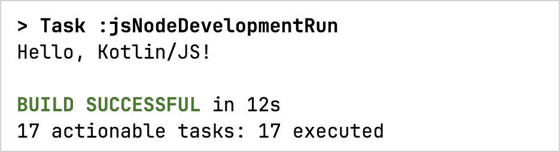

### Open the project in an IDE

You can open your project in any IDE that supports Gradle.

If you use IntelliJ IDEA:

1. Select File | Open.
2. Find the project directory.
3. Click Open.

IntelliJ IDEA automatically detects if it's a Kotlin/JS project. If you encounter a problem with the project, IntelliJ IDEA displays the error message in the Build pane.

## What's next?

- Set up your Kotlin/JS project.
- Learn how to debug Kotlin/JS applications.
- Learn how to write and run tests with Kotlin/JS.
- Learn how to write Gradle build scripts for real-life Kotlin/JS projects.
- Read more about the Gradle build system.

21 May 2026

Kotlin/JavaScriptSet up a Kotlin/JS project

© 2010–2026 JetBrains s.r.o. and Kotlin Programming Language contributors  
Licensed under the Apache License, Version 2.0.  
https://kotlinlang.org/docs/js-get-started.html